# Computer Programming and Web Developement

# Friday School Spring 2021

# Lesson 3

3/19/2021

## Presentation

Today, you should be able to load the presentation on your own laptop.

Go to the https://friday-school.github.io/showcase/Lesson3.slides.html

## How internet works

Before we go further, we also need to understand how internet works

### Server and clients

- Servers are computers placed in special locations to provide web service.
- Clients are web browsers, cell phones, tablets, ...

```python
%%html
<iframe width="600" height="350" src="https://www.youtube.com/embed/P2OlHrZQDUM?start=100" frameborder="0" allow="accelerometer; autoplay; clipboard-write; encrypted-media; gyroscope; picture-in-picture" allowfullscreen></iframe>
```

[video not shown]

You probably know that Amazon is a website for shopping.

https://amazon.com

You probably do not know that Amazon is the biggest web service provider in the world

```python
%%html
<iframe width="560" height="315" src="https://www.youtube.com/embed/mxCfygY1dk8" frameborder="0" allow="accelerometer; autoplay; clipboard-write; encrypted-media; gyroscope; picture-in-picture" allowfullscreen></iframe>
```

[video not shown]

### What do servers do

[figure not shown]

1. The codes run on the left are called **front-end**/**clident-side** code.
2. The codes run on the right are called **back-end**/**server-side** code.

[figure not shown]

Server-side codes usually are written in Python, Node.js, Ruby, Pearl, PHP, C++, ...

A server-side Python sample code:

```
def handler(event, context):
    searchTerm = event['searchTerm']
    results = GoogleSearchEngine(searchTerm)
    return {
        "data": results,
        "info": "success"
    }
```

A live demo with https://google.com

- open a new tab in browser
- go to https://google.com
- open web console in Chrome
  1. Click the Chrome Menu in the upper right corner
  2. More Tools
  3. Developer tools
  4. Network
- type "cats" in the search bar and check Network

### What do clients do

Now, we have a lot information from the server in the https://google.com example

What clients do are to turn the information into links, images, videos, and webpage layouts at the front end, i.e. the browser or phone

1. go to "Inspector"
2. check the graphical components and font-end codes.
3. check the Google navigation code

You have seen the client-side/front-end code such as

```
document.body.innerHTML = ''
button = document.createElement('button')
button.innerText='Click Me'
document.body.appendChild(button)
button.style.backgroundColor='white'
button.style.color='blue'
button.style.height = '100px'
button.style.width = '200px'
```

```python
%%html
<button style="color:blue;background-color:white;width:200px;height:100px"
onclick="document.getElementById('demo').innerHTML = Date()">Show Time</button>
<button style="color:blue;background-color:white;width:200px;height:100px"
onclick="document.getElementById('demo').innerHTML = ''">Hide Time</button>
<p id="demo"></p>
```

## Code Examples

Now, we will show some code examples and what kind of work they do

since different languages are for different purposes.

The selection of a language depends on what you like to do.

### A html front-end/client side example

- Language used: HTML, CSS
1. Go to htmlExample.html
2. Click Raw
3. Ctrl-S saves the file
4. open this file in web browser

### A javascript front-end/client side example

- Language used: Javascript, HTML, CSS
1. Go to [javascriptExample.html](https://github.com/Friday-School/showcase/blob/main/htmlExample.html)
2. Click Raw
3. Ctrl-S saves the file
4. open this file in web browser

### A javascript front-end/client side game example

- Language used: Javascript, HTML, CSS
1. Go to [gameExample.html](https://github.com/Friday-School/showcase/blob/main/htmlExample.html)
2. Click Raw
3. Ctrl-S saves the file
4. open this file in web browser

### A python back-end/server side example

```python
%matplotlib notebook

import matplotlib.pyplot as plt

x = [1,2,3,5,6,7,8,9,10,12,13,14,15,16,18,19,21,22]
y = [100,90,80,60,60,55,60,65,70,70,75,76,78,79,90,99,99,100]
```

```python
import numpy
mymodel = numpy.poly1d(numpy.polyfit(x, y, 3))
myline = numpy.linspace(1, 22, 100)
```

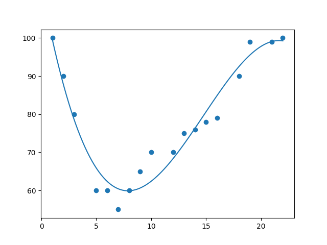

```python
plt.scatter(x, y)
plt.plot(myline, mymodel(myline))
```

## Project ideas

- HTML/CSS only website. Some ideas:
  - Personal Blog
  - Home School Teaching Schedule
  - Science Class Report
  - Familiy Website
  - Fashion/Clothing Store
  - Wedding Invitation Page
  - Photo Portfolio
  - Restaurant Website
  - ...
- Javascript/HTML/CSS website. Some ideas:
  - Web calculator
  - Math Problems
  - New Year Countdown
  - Eating out Bill Splitter
  - Tic Tac Toe Game
  - World Clocks
  - Tetris Game
  - Javascript Clock
  - Ping Pong game
  - Maze Game
  - Music Player
  - 3D modeling
  - ...
- Python. Some ideas:
  - Twitter Bot
  - Password Generator
  - Guessing Games
  - Text-based Adventure Game
  - Dice Rolling Simulator
  - Python Story Generator
  - YouTube video downloader
  - Scientific Problems
  - Engineering Problems
  - Machine Learning
  - Data Science
  - ...
- Other ideas:
  - Create PDF file for writings.
  - Send/Receive Emails.
  - Presentations.
  - ...

## Homework

1. Post your project idea [here](https://github.com/Friday-School/WebDevelopement/issues/new)
   - the ideas above do not mean to limit your thoughts
   - you can have any ideas and discuss with me on class website
   - you have three weeks to think about it
2. The couse contents for the first three classes can be found below:
   1. [Lesson 1](https://friday-school.github.io/showcase/Lesson1.html)
   2. [Lesson 2](https://friday-school.github.io/showcase/Lesson2.html)
   3. [Lesson 3](https://friday-school.github.io/showcase/Lesson3.html)
3. A good idea could be something that you will actually use it.
4. Next class:
   1. Programming basics.
   2. Create your own website
   3. Start adding your project to your website